# QTM 385 - Experimental Methods

Lecture 16 - Interference

Danilo Freire

danilo.freire@emory.edu

Emory University

# How are you doing? 😊

# Brief recap 📚

## Brief recap 📚

- Natural experiments framework
  - True vs “as-if” randomness in treatment assignment
  - Core assumption: exogeneity of assignment mechanism
  - Examples: Lottery-based charter school studies, border discontinuity designs
- Quasi-experimental approaches
  - Regression discontinuity (RDD): Leveraging threshold-based assignment
  - Difference-in-differences (DID): Utilising parallel trends assumption
- Methodological challenges
  - Selection bias in observational data
  - SUTVA violations from treatment spillovers
  - Power limitations in natural variation contexts
- Empirical examples
  - Angrist et al. (2013): School lottery IV analysis
  - Card & Krueger (1994): Minimum wage DID study
  - Mignozzetti et al. (2024): RDD in legislative analysis
- Validation strategies
  - Placebo tests for assumption verification
  - Pre-treatment trend analysis for DID
  - Robustness checks for sensitivity assessments
- Ethical considerations
  - Responsible communication of limitations
  - Secondary data ethics compliance
  - Policy impact assessments for natural experiments

# Today’s plan 📅

## Interference and spillovers

- SUTVA violations happen quite often
- So it is better to model interference explicitly
- We will see how to deal with spillovers using multi-level designs, spatial spillovers, within-subject designs, repeated-measures experiments, and waitlist designs
- We will also discuss the assumptions behind these designs and how to estimate treatment effects in these cases
- Let’s get started! 😎

[figure not shown]

Source: https://www.caliper.com/Maptitude/Crime/default.htm

# Interference

## Interference

### When treatment effects spill over

- Remember SUTVA?
  - Stable unit treatment value assumption
- The stable part means that potential outcomes should be independent of the treatment
- As you can imagine, this poses risks to causal identification
- This happens quite often in social and public health interventions:
  - Peer effects in education
  - Contagion in public health
  - Spillovers in policy evaluations
  - Network effects in marketing and technology

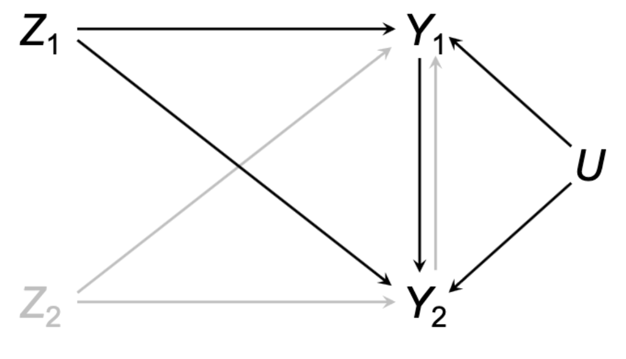

Source: [Arronow et al. (2021)](https://arxiv.org/pdf/2001.05444)

## A motivating example

- Imagine you are trying to improve school grades
- You think that awarding a prize to students will help motivate them
- You randomly assign students to treatment and control groups
- You find a positive effect of the program on test scores
- But you also find that depending on who gets the treatment, the effect varies

| Student | Grades if Alice wins prize | Grades if Bob wins prize | Grades if Charlie wins prize | Grades if no prize awarded |
| --- | --- | --- | --- | --- |
| Alice | 10 | 5 | 7 | 7 |
| Bob | 5 | 5 | 5 | 5 |
| Charlie | 9 | 5 | 9 | 9 |

## Example

- You find that the results vary depending on who wins the prize
- Let’s calculate the ATEs in this case?

| Student | Grades if Alice wins prize | Grades if Bob wins prize | Grades if Charlie wins prize | Grades if no prize awarded |
| --- | --- | --- | --- | --- |
| Alice | 10 | 5 | 7 | 7 |
| Bob | 5 | 5 | 5 | 5 |
| Charlie | 9 | 5 | 9 | 9 |

- If we simply calculate the ATE using the last column as $Y_{i}(0)$ and the column corresponding to $i$’s award as $Y_{i}(1)$, we have: $\frac{((10 - 7) + (5 - 5) + (9 - 9))}{3} = 1$
- However… if we randomise the treatment, we have these results:
- If Alice wins the prize, the ATE is $10 - \frac{5+9}{2} = 3$
- If Bob wins the prize, the ATE is $5 - \frac{5+5}{2} = 0$
- If Charlie wins the prize, the ATE is $9 - \frac{7+5}{2} = 3$
- The average of these three is $2$, which is different from the first calculation

## Not all spillovers are bad!

- As we have seen, many social phenomena are interdependent
- But some are explicitly designed to leverage spillovers
  - Contamination: The effect of being vaccinated on one’s probability of contracting a disease depends on whether others are vaccinated
  - Network effects: The value of a product or service increases as more people use it (social media, telecommunication)
  - Hot-spots policing: The effect of increased police presence in one area can reduce crime in nearby areas
  - Deterrence: The effect of a harsher punishment on one individual can deter others from committing crimes

[figure not shown]

Source: [Collazos et al. (2021)](https://link.springer.com/article/10.1007/s11292-019-09390-1)

# How to deal with interference? (good and bad!)

## How to deal with interference?

- Interference can be a nuisance, but also an opportunity
- So it is a good idea to model it explicitly in our analysis
- In this case, we wouldn’t need to assume “no spillovers”, but rather “not modelled spillovers”
- Good design can help us leverage spillovers to our advantage
- There are several methods to do this:
  - Clustered randomisation (this one you already know!)
  - Multi-level designs (e.g., schools within districts)
  - Within-subject designs (e.g., repeated measures)
  - Waitlist designs (e.g., staggered rollouts)
- Let’s see them in more detail 😎

## Multi-level designs

- Multi-level designs are nested experiments
- This means that we have multiple levels of randomisation
- For example, in a school-based intervention:
  - Schools are randomised to treatment or control
  - Within schools, students are also randomised
- Political interventions can also be nested:
  - We randomise the treatment at the district level
  - Then we randomise the treatment again at the voter level
- But we need to expand our potential outcomes notation to account for this…

## An example

### Get-out-to-vote campaign

- Imagine we are running an experiment to test the effect of a get-out-to-vote campaign on voter turnout
- We have a multi-level design:
  - Households are randomised to treatment or control
  - Within households, individuals are also randomised
- Focus on two-voter households where residents share addresses
- Random assignment groups:
  - 5,000 households: both voters targeted
  - 5,000 households: neither targeted
  - 10,000 households: one randomly targeted
- Creates four 10,000-person groups:
  - Mail received by both
  - Neither receives mail
  - Mail with untreated housemate
  - Untreated with treated housemate
- *Multi-level design* features:
  - Two-stage randomisation (household then individual)
  - Expandable to additional levels like postcode

## An example

### Get-out-to-vote campaign

- Potential outcomes depend on both own and housemate’s treatment status
- Revised notation system accounts for dual treatment influences ($Y_{ab}$ where):
  - `a` = housemate’s treatment status (0=control, 1=treated)
  - `b` = own treatment status (0=control, 1=treated)

| Notation | Housemate | Self | Interpretation |
| --- | --- | --- | --- |
| $Y_{00}$ | Control | Control | Baseline outcome |
| $Y_{01}$ | Control | Treated | Direct treatment effect |
| $Y_{10}$ | Treated | Control | Spillover effect |
| $Y_{11}$ | Treated | Treated | Combined effects |

- Key assumption: Strict household containment
  - Outcomes only affected by within-household interventions
  - No interference from external treatment assignments

## Defining causal effects

- From the four potential outcomes, key estimands emerge:
  - $Y_{01} - Y_{00}$: Direct effect of treatment when housemate is untreated
  - $Y_{11} - Y_{10}$: Treatment effect when housemate receives mail
  - $Y_{10} - Y_{00}$: Spillover effect on untreated with treated housemate
  - $Y_{11} - Y_{01}$: Spillover interaction among treated pairs
- Critical considerations:
  - Effects depend on housemate’s treatment status
  - Estimands capture combined influences of:
    - Direct intervention impacts
    - Communication spillovers
    - Shared resource effects
  - Does *not* isolate specific mechanisms behind spillovers

## Implementation challenges

### Practical considerations

- Common implementation hurdles:
  - Treatment contamination between groups
  - Differential attrition across conditions
  - Compliance monitoring complexities
  - Resource allocation for multi-level tracking
- Ethical considerations:
  - Informed consent for network members
  - Privacy protections for household data
  - Equity implications of spillover effects
- Design limitations to address:
  - Sample size requirements for cluster effects
  - Measurement challenges for indirect impacts
  - Temporal aspects of spillover timing
  - Correct estimation of standard errors, as subjects are probably correlated in many ways

**Note:** Pre-registration is crucial for complex designs

# Spatial spillovers

## Spatial spillovers

- So far, we have weakened the SUTVA assumption by considering interference in a small setting (households)
- Sometimes, spillovers are not confined to specific units, but spread across space
- This is particularly common in urban settings:
  - Crime in adjacent neighbourhoods
  - Pollution in nearby areas
  - Economic development in neighbouring regions
  - Health outcomes in surrounding communities
- While it seems tempting to just include a measure of proximity in our models, it is not that simple…
  - Not easy to be very precise about spillover effects
  - Not valid when spillovers are not spatially confined (e.g., pollution)
  - Physical proximity does not always make sense (e.g., social networks, phones)

## Motivating example

- Imagine you want to improve healthcare in five villages
- Assume also that the proper distance between villages is known, so this is not a spatial problem
- Subjects reside in villages A, B, C, D and F, and E is unoccupied
- Only one village will receive the treatment, which is a new healthcare facility
- There are three types of potential outcomes:
  - $Y_{01}$: Healthcare level of village X if it receives the treatment
  - $Y_{10}$: Healthcare level of village X if the adjacent village receives the treatment
  - $Y_{00}$: Healthcare level of village X if village X or its neighbours do not receive the treatment

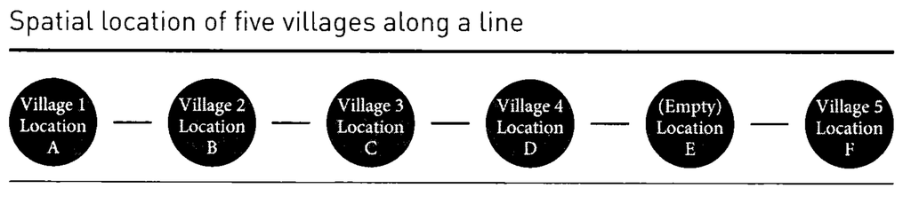

## Potential outcomes

| Village | Untreated ($Y_{00}$) | Adjacent village treated ($Y_{10}$) | Treated ($Y_{01}$) |
| --- | --- | --- | --- |
| A | 0 | 2 | 0 |
| B | 6 | 2 | 10 |
| C | 0 | 4 | 4 |
| D | 6 | 6 | 6 |
| F | 6 | NA | 3 |

- Notice that some villages can never have some outcomes
- Village E is unoccupied, so it is not included in the analysis
- NA indicates that Village F can never be adjacent to a treated village
- In this case, location F can never manifest a $Y_{10}$ outcome
- As this potential outcome can never be observed, we exclude F from the definition of the average treatment effect $E[Y_{10} - Y_{00}]$

## Potential outcomes

- Second, the probability of assignment to each treatment condition varies from one observation to the next
- For instance, village A has a 0.20 probability of being exposed to spillovers from an adjacent treated location, whereas the village at location B has a 0.40 probability
- As we have seen previously, we should weight observations by inverse probability of assigned experimental condition, excluding subjects with zero probability (e.g., F)

[output not shown]

## Calculating $Y_{01} - Y_{00}$ and $Y_{10} - Y_{00}$

### Average and spillover effects

- Now we can calculate the average treatment effect in the presence of spillovers
- We need to weight the observations by the inverse probability of assignment to the treatment condition
- Imagine that Village D is treated
- Villages A, B and F have $Y_{00}$ as the potential outcome, as they are not directly affected by spillovers
- Village C, in contrast, is not included in the calculation because it does not have a $Y_{00}$ potential outcome (untreated), but expresses a $Y_{10}$ potential outcome instead (spillover effect)
- The weighted difference-in-means estimator of $E[Y_{01} - Y_{00}]$ adjusts for the fact that the probabilities of being untreated are 0.60, 0.40, and 0.80 for Villages 1, 2, and 5, respectively
- So the effect is:

$$\hat{E}[Y_{01} - Y_{00}] = \frac{\frac{6}{0.2}}{\frac{1}{0.2}} - \frac{\frac{0}{0.6} + \frac{6}{0.4} + \frac{6}{0.8}}{\frac{1}{0.6} + \frac{1}{0.4} + \frac{1}{0.8}} = 1.85.$$

- If we wanted to estimate the spillover effect, we would calculate $E[Y_{10} - Y_{00}]$ instead
- Village D is treated, so we would exclude it from the calculation
- Village F is also excluded as it cannot be adjacent to a treated village

$$\hat{E}[Y_{10} - Y_{00}] = \frac{\frac{4}{0.4}}{\frac{1}{0.4}} - \frac{\frac{0}{0.6} + \frac{6}{0.4}}{\frac{1}{0.6} + \frac{1}{0.4}} = 0.40.$$

# Within-subject designs and repeated-measures experiments

## Within-subject designs

- Within-subject designs are a type of study that repeatedly measures the same subjects over time and randomisation occurs at a certain point in time
- The good thing about this design is that it controls for individual differences that could confound the results
- This type of experiment is rather uncommon in the social sciences, but it is quite common in psychology
- Instead, social scientists usually rely on interrupted time-series designs to study the effects of interventions
- This is similar to a regression discontinuity in time
- Let’s see how they work… (and why they are a bit problematic)

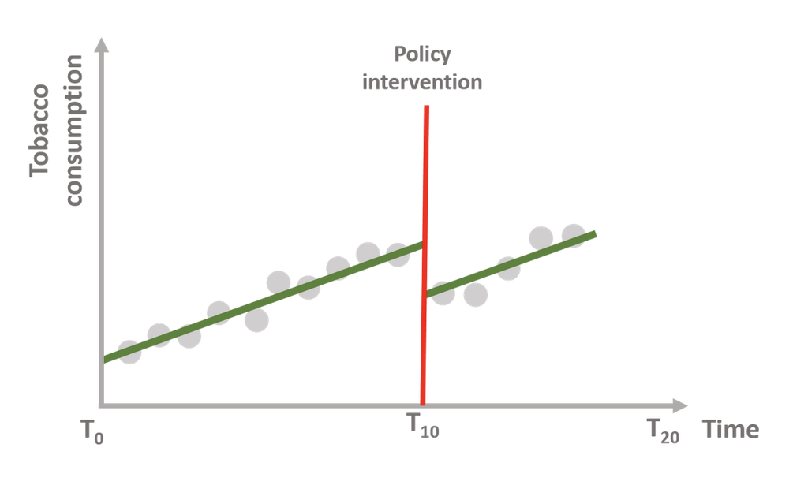

Source: https://ds4ps.org/pe4ps-textbook/docs/p-020-time-series.html

- The problem with this design is that it is hard to establish causality
- Confounding factors can affect the results, as something may change at the same time as the intervention

## Within-subject designs

### Assumptions

- The key assumption in within-subject designs is that the intervention is the only thing that changes
- Therefore, we need to make two additional assumptions:
  - No-anticipation: Subjects do not know when the intervention will occur, so they cannot change their behaviour in anticipation
  - For example, if we are studying the effect of a new policy on crime rates, we need to make sure that criminals do not know when the policy will be implemented
  - No persistence: Potential outcomes in one period are unaffected by treatments administered in prior periods
  - This is a bit tricky, as we are assuming that the effect of the treatment disappears after a certain period
  - Experimenters often include “washout periods” between experimental sessions so as to allow the previous period’s effects to dissipate

## Variations of repeated-measures experiments

- [Clifford et al (2021)](https://doi.org/10.1017/S0003055421000241) evaluate how different “pre-post” designs can improve experimental estimates, mainly by reducing standard errors
- Regular experiments (“post only”) have relatively low precision because the outcome is measured just once
- This is particularly problematic when the outcome is noisy or if the experiment involves multiple treatment arms, moderators, or small treatment effects
- Pre-post designs measure the outcome prior to the experimental manipulation at point $t_0$ and after the manipulation at point $t_1$ (as we’ve just seen)
- The pre-post design can also be a between-subjects design because some respondents are never exposed to the treatment; respondents difference scores are compared between groups

## Variations of time-series experiments

- Some scholars worry that measuring the outcome prior to the experiment could alter estimated treatment effects
- This is true in some cases: the no-persistence assumption is likely violated when you the treatment is giving information or training, for example
- The quasi-pretest-posttest design is a variation of the pre-post design that tries to avoids this problem by providing a similar, but not identical, treatment in the pretest phase
- The authors decided to test these designs in a replication of six studies to see how they perform in practice
- If different designs yield largely the same results, researchers can be more confident in the external validity of these findings and choose designs based on other features, like precision

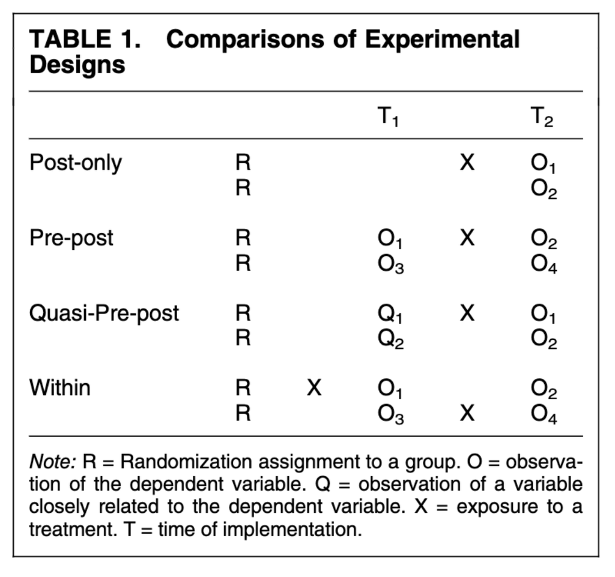

Source: [Clifford et al (2021)](https://doi.org/10.1017/S0003055421000241)

## Variations of time-series experiments

### Replication of six studies

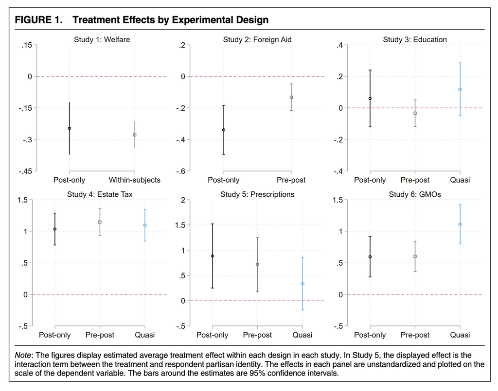

## Variations of time-series experiments

### Standard errors

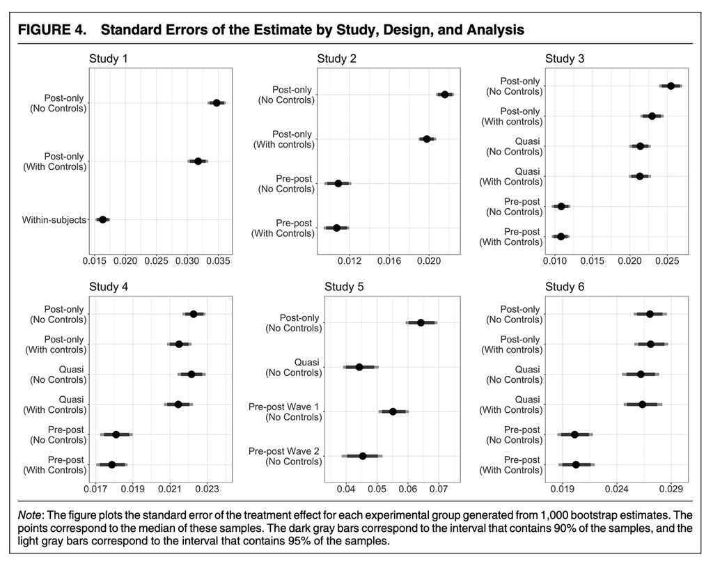

# Waitlist designs

## Waitlist designs

- The final type of design we will discuss today is the waitlist design, also known as the stepped-wedge design
- Their scientific value comes from their ability to track treatment effects among several subjects as they play out over time
- Waitlists play a diplomatic role because they overcome the problem of withholding treatment from a control group (remember our ethics discussion?)
- In this design, every subject is treated eventually; random assignment determines when they receive treatment
- It is a hybrid between a within-subject and a between-subject design, and it is widely used in public health interventions (e.g., vaccine rollouts)

## Waitlist designs

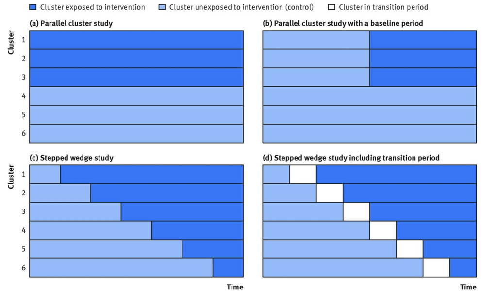

Source: [Hemming et al (2014)](https://doi.org/10.1136/bmj.h391)

## Example: TV advertising and candidate support

- Imagine you are a political consultant and you want to test the effect of TV advertising on candidate support
- Ads are aired during three weeks, and outcomes (support for the gubernatorial candidate as gauged by opinion polls) are assessed at the end of each week
- Eight media markets are randomly assigned to one of four conditions:
  - Two media markets are randomly assigned to air ads for three weeks starting in week 1
  - Two markets air ads for two weeks starting in week 2
  - Two markets air ads for one week starting in week 3
  - And two markets air no ads at all
- There are just three relevant potential outcomes:
  - $Y_{00}$: untreated during preceding and current periods
  - $Y_{01}$: untreated during the preceding period but treated during the current period
  - $Y_{11}$: treated in both the preceding and current periods
  - Given the design, we never observe the potential outcome $Y_{10}$ because media markets never cease to run ads once they start

## Advertising waitlist experiment’s random assignments and observed outcomes

**Assigned treatment**

| Market | Week 1 | Week 2 | Week 3 |
| --- | --- | --- | --- |
| 1 | 01 | 11 | 11 |
| 2 | 00 | 00 | 01 |
| 3 | 00 | 01 | 11 |
| 4 | 00 | 00 | 01 |
| 5 | 00 | 00 | 00 |
| 6 | 01 | 11 | 11 |
| 7 | 00 | 00 | 00 |
| 8 | 00 | 01 | 11 |

**Observed outcomes**

| Market | Week 1 | Week 2 | Week 3 |
| --- | --- | --- | --- |
| 1 | 7 | 9 | 4 |
| 2 | 7 | 5 | 7 |
| 3 | 1 | 2 | 10 |
| 4 | 4 | 3 | 10 |
| 5 | 3 | 3 | 3 |
| 6 | 10 | 8 | 10 |
| 7 | 2 | 3 | 4 |
| 8 | 3 | 1 | 3 |

**Probabilities of assignment to treatment condition**

| Treatment Condition | Week 1 | Week 2 | Week 3 |
| --- | --- | --- | --- |
| Pr(00) | 0.75 | 0.50 | 0.25 |
| Pr(01) | 0.25 | 0.25 | 0.25 |
| Pr(11) | 0 | 0.25 | 0.50 |

## Estimating the cumulative effect of TV advertising

- Finally, we will estimate the cumulative effect of TV advertising, which is $Y_{11} - Y_{00}$, that is, the effect of being treated in both the preceding and current periods
- We do the same thing again, but now we consider the $Y_{11}$ potential outcomes
- However, we must restrict our attention to the second and third weeks, because this type of treatment cannot occur in the first week

$$\begin{aligned}
\widehat{E}[Y_{11} - Y_{00}] &= \frac{\frac{9 + 8}{0.25} + \frac{4 + 10 + 10 + 3}{0.50}}{\frac{2}{0.25} + \frac{4}{0.50}} \\
&- \frac{\frac{5 + 3 + 3 + 3}{0.50} + \frac{3 + 4}{0.25}}{\frac{4}{0.50} + \frac{2}{0.25}} = 4.13.
\end{aligned}$$

## Conclusion

- Spillovers are a common problem in social science research
- They can be positive or negative, and they can be modelled explicitly in our analysis
- There are several methods to deal with spillovers, such as multi-level designs, within-subject designs, repeated-measures experiments, and waitlist designs
- Each design has its advantages and disadvantages, and the choice of design should be based on the research question and the context
- You can use [DeclareDesign](https://declaredesign.org/r/designlibrary/) to simulate spillover designs and pretest posttest designs
- The statistical analysis of waitlist designs are a little tricky, but you can use the [swCRTdesign](https://cran.r-project.org/web/packages/swCRTdesign/index.html) package in R to help you with that

# And that’s all for today! 🎉